# ggplot2_20190925_101_kim

# Chapter 8. ggplot2

Throughout the book, we will be creating plots using the **ggplot2** package.

```r
library(dplyr)
library(ggplot2)
```

**ggplot2** breaks plots into components in a way that permits beginners to create relatively complex and aesthetically pleasing plots using syntax that is intuitive and comparatively easy to remember.

## 8.1. The components of a graph

Data visualization shows us pretty much all the information in the data table. The first step in learning **ggplot2** is to be able to break a graph apart into components.

```r
library(dslabs)
data(murders)
```

## 8.2. `ggplot` objects

The first step in creating a **ggplot2** graph is to define a `ggplot` object. We do this with the function `ggplot`, which initializes the graph. The first argument is used to specity what data is associated with this object.

We can also pipe the data in as the first argument:

```r
murders %>% ggplot()
```

We can assign our plot to an object:

```r
p <- ggplot(data = murders)
class(p)
print(p)
```

## 8.3. Geometries

In `ggplot2` we create graphs by adding *layers*. Layers can define geometries, compute summary statistics, define what scales to use, or even change styles. To add layers, we use the symbol `+`.

> DATA %>% `ggplot()` + LAYER 1 + LAYER 2 + … + LAYER N

Usually, the first added layer defines the geometry. Our possible geometries are scatterplot, barplot, histogram, smooth densities, qqplot, and boxplot.

Geometry function names follow the pattern : `geom_X` where X is the name of the geometry. Some examples include `geom_point`, `geom_bar` and `geom_histogram`.

For `geom_point` to run properly we need to provide data and a mapping.

## 8.4. Aesthetic mappings

Aesthetic mappings describe how properties of the data connect with features of the graph, such as distance along an axis, size or color. The `aes` function connects data with what we see on the graph by defining aesthetic mappings, and will be one of the functions you use most often when plotting.

The outcome of the `aes` function is often used as the argument of a geometry function.

```r
murders %>% ggplot() +
  geom_point(aes(x = population/10^6, y = total))
```

[output not shown]

We can drop the `x=` and `y=` if we wanted. Onstead of defining plot from scratch, we can also add a layer to the `p` object that was defined above as `p <- ggplot(data = murders)`:

```r
p + geom_point(aes(population/10^6, total))
```

[output not shown]

Like `dplyr` functions, `aes` also uses the variable names from the object component : we can use `population` and `total` without having to call them using accessor `$`.

## 8.5. Layers

A second layer in the plot involves adding a label to each point to identify the state.

The `geom_label` and `geom_text` functions permit us to add text to the plot with and without a rectangle behind the text respectively.

Because each point has a label, we need an aesthetic mapping to make the connection between points and labels.

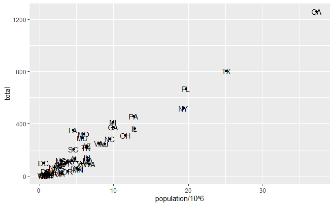

```r
p + geom_point(aes(population/10^6, total)) +
  geom_text(aes(population/10^6, total, label = abb))
```

> 8.5.1. Tinkering with arguments

Each geometry function has many arguments other than `aes` and `data`. They tend to be specific to the function.

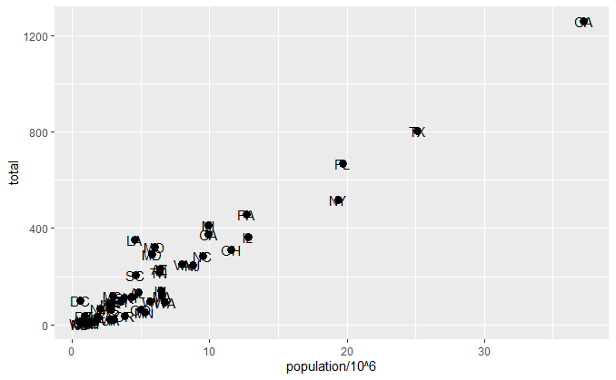

```r
p + geom_point(aes(population/10^6, total), size = 3) +
  geom_text(aes(population/10^6, total, label = abb))
```

`size` is not a mapping : whereas mappings use data from specific observations and need to be inside `aes()`, operations we want to affect all the points the same way do not need to be included inside ``aes`.

`nudge_x` argument moves the text slightly to the right or to the left:

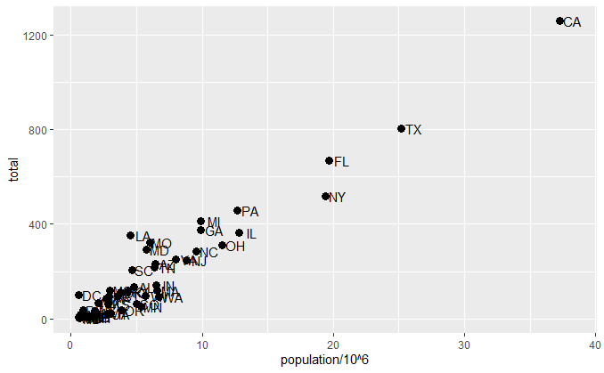

```r
p + geom_point(aes(population/10^6, total), size = 3) +
  geom_text(aes(population/10^6, total, label = abb), nudge_x = 1)
```

## 8.6. Global versus local aesthetic mappings

If we define a mapping in `ggplot`, all the geometries that are added as layers will default to the mapping. We redefine p :

```r
p <- murders %>% ggplot(aes(population / 10^6, total, label = abb))
```

and we can simply write :

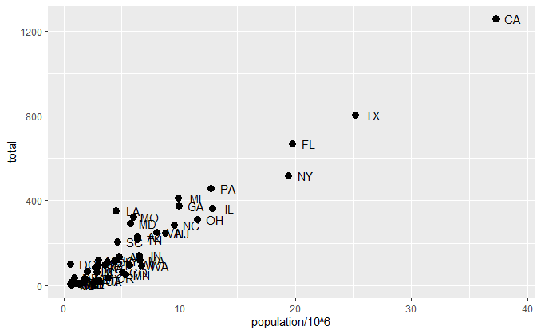

```r
p + geom_point(size = 3) +
  geom_text(nudge_x = 1.5)
```

We can override the global mapping by defining a new mapping within each layer. These local definitions override the global:

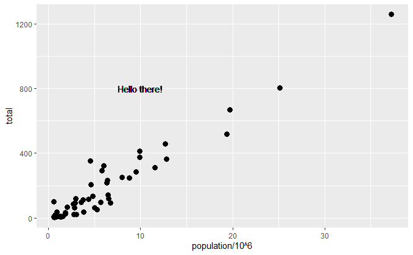

```r
p + geom_point(size = 3)+
  geom_text(aes(x = 10, y = 800, label = "Hello there!"))
```

## 8.7. Scales

Our desired scales are in log-scale.

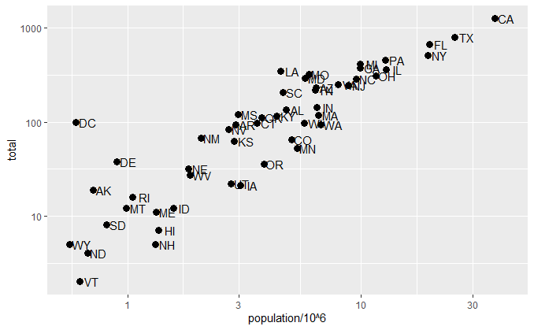

```r
p + geom_point(size = 3) +
  geom_text(nudge_x = 0.05) +
  #scale_x_log10()
  scale_x_continuous(trans = "log10") +
  #scale_y_log10()
  scale_y_continuous(trans = "log10")
```

## 8.8. Labels and titles

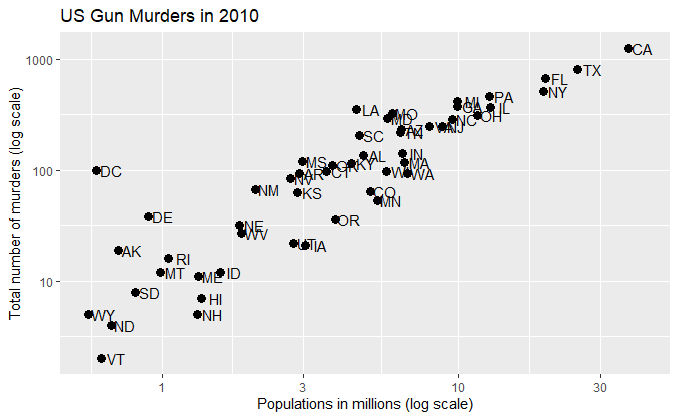

```r
p + geom_point(size = 3) +
  geom_text(nudge_x = 0.05) +
  scale_x_log10() +
  scale_y_log10() +
  xlab("Populations in millions (log scale)") +
  ylab("Total number of murders (log scale)") +
  ggtitle("US Gun Murders in 2010")
```

## 8.9. Categories as colors

We can change the color of the points using the `col` argument in the `geom_point` function.

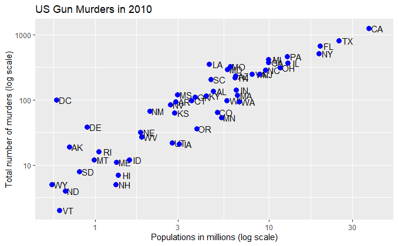

```r
p <-  murders %>% ggplot(aes(population/10^6, total, label = abb)) +
  geom_text(nudge_x = 0.05) +
  scale_x_log10() +
  scale_y_log10() +
  xlab("Populations in millions (log scale)") +
  ylab("Total number of murders (log scale)") +
  ggtitle("US Gun Murders in 2010") +
  geom_point(size = 3, color ="blue")

p
```

If we assign a categorical variable to color, it automatically assigns a different color to each category and also adds a legend.

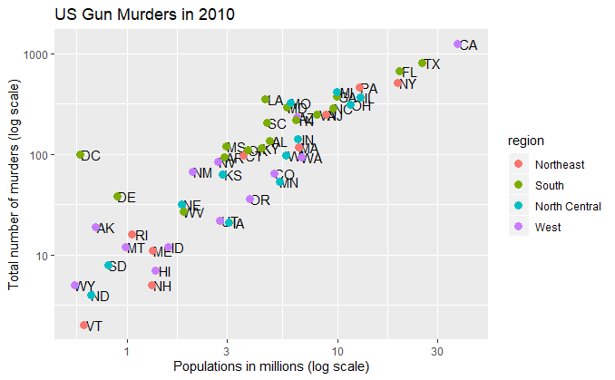

```r
p + geom_point(aes(col=region), size = 3)
```

## 8.10. Annotation, shapes, and adjustments

We can add shapes or annotation to figures that are not derived directly from the aesthetic mapping ; examples include labels, boxes, shaded areas and lines. To add a line we use the `geom_abline` function. ggplot2 uses `ab` in the name to remind us we are supplying the intercept and slope.

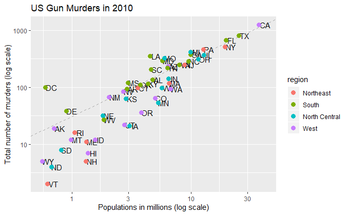

```r
r <- murders %>%
  summarize(rate = sum(total) / sum(population) * 10^6) %>%
  pull(rate)
p + geom_point(aes(col = region), size = 3) +
  geom_abline(intercept = log10(r), lty = 2, color = "darkgrey") +
  geom_point(aes(col=region), size = 3)
```

## 8.11. Add-on packages

The style of a ggplot2 graph can be changed using the `theme` functions. In this book we use a function in the dslabs package that automatically sets a default theme:

```r
ds_theme_set()
```

Many other themes are added by the package ggthemes.

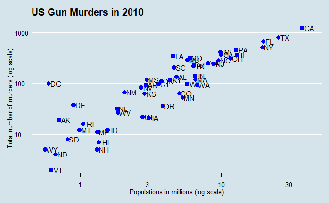

```r
#install.packages("ggthemes")
library(ggthemes)
p + theme_economist()
```

## 8.12. Putting it all together

[figure not shown]

```r
#install.packages("ggrepel")

library(ggthemes)
library(ggrepel)

r <- murders %>%
  summarize(rate = sum(total) /  sum(population) * 10^6) %>%
  pull(rate)

murders %>% ggplot(aes(population/10^6, total, label = abb)) +
  geom_abline(intercept = log10(r), lty = 2, color = "darkgrey") +
  geom_point(aes(col=region), size = 3) +
  geom_text_repel() +
  scale_x_log10() +
  scale_y_log10() +
  xlab("Populations in millions (log scale)") +
  ylab("Total number of murders (log scale)") +
  ggtitle("US Gun Murders in 2010") +
  scale_color_discrete(name = "Region") +
  theme_economist()
```

## 8.13. Quick plots with `qplot`

The `qplot` function sacrifices the flexibility provided by the `ggplot` approach, but allows us to generate a plot quickly.

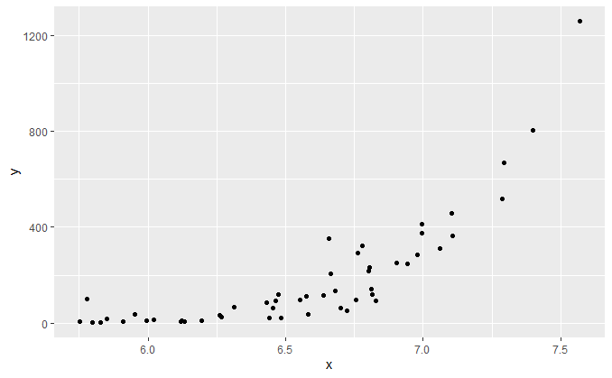

```r
data(murders)
x <- log10(murders$population)
y <- murders$total

qplot(x, y)
```

## 8.14. Grids of plots

The gridExtra package permits us to graph plots next to each other.

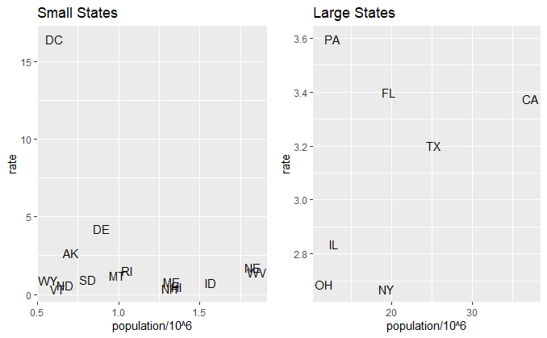

```r
#install.packages("gridExtra")

library(gridExtra)
p1 <- murders %>%
  mutate(rate = total/population*10^5) %>%
  filter(population < 2*10^6) %>%
  ggplot(aes(population/10^6, rate, label = abb)) +
  geom_text() +
  ggtitle("Small States")

p2 <- murders %>%
  mutate(rate = total/population*10^5) %>%
  filter(population > 10*10^6) %>%
  ggplot(aes(population/10^6, rate, label = abb)) +
  geom_text() +
  ggtitle("Large States")

grid.arrange(p1, p2, ncol = 2)
```